# Medulloblastoma Subtype Immune Cell Composition

Rehman Qureshi

## Set Up

This script assumes that 01-immune-deconv.R has been executed and uses the existing output files in the results folder.

```r
# load packages
suppressWarnings(library(tidyverse))
suppressWarnings(library(ggbeeswarm))
suppressWarnings(library(vegan))
suppressWarnings(library(ggplot2))
suppressWarnings(library(stringr))

# Check if results file exist and load them
if (!dir.exists('results')) {
    stop("Error: The  results directory was not found. Please execute '01-immune-deconv.R'", call. = FALSE)
}
if (file.exists('results/quantiseq_output.rds')) {
    qs_data <- readRDS('results/quantiseq_output.rds')
} else {
    stop("Error: results/quantiseq_output.rds was not found. Please execute '01-immune-deconv.R'", call. = FALSE)
}
if (file.exists('results/xcell_output.rds')) {
    xcell_data <- readRDS('results/xcell_output.rds')
} else {
    stop("Error: results/xcell_output.rds was not found. Please execute '01-immune-deconv.R'", call. = FALSE)
}

# filter files to include only Medulloblastoma samples
qs_data <- qs_data %>%
    dplyr::filter(cancer_group == 'Medulloblastoma')
xcell_data <- xcell_data %>%
    dplyr::filter(cancer_group == 'Medulloblastoma') %>%
    dplyr::filter(!str_detect(cell_type,'score')) # remove variables that are not proportions
```

## Statistical analysis of differential Immune Cell Type Proportions determined by Quantiseq

To test the whether the molecular subtype of the tumor has an effect on the distribution of fractions of the immune cell types we can employ Permutational Multivariate Analysis of Variance (PERMANOVA) as implemented in the vegan package.

```r
qs_data_trans <- qs_data
qs_data_trans <- qs_data_trans %>%
    dplyr::select(Kids_First_Biospecimen_ID,molecular_subtype,cell_type,fraction) %>%
    tidyr::pivot_wider(
        names_from='cell_type',
        values_from='fraction',
        id_cols=c('Kids_First_Biospecimen_ID','molecular_subtype')
    )
qs_dist_mat <- vegan::vegdist(qs_data_trans[,3:ncol(qs_data_trans)],method = 'bray')
set.seed(117)
permanova_result <- vegan::adonis2(qs_dist_mat ~ qs_data_trans$molecular_subtype)
print(permanova_result)
```

```
## Permutation test for adonis under reduced model
## Permutation: free
## Number of permutations: 999
##
## vegan::adonis2(formula = qs_dist_mat ~ qs_data_trans$molecular_subtype)
##           Df SumOfSqs      R2      F Pr(>F)
## Model      3   0.7078 0.14752 15.805  0.001 ***
## Residual 274   4.0901 0.85248
## Total    277   4.7979 1.00000
## ---
## Signif. codes:  0 '***' 0.001 '**' 0.01 '*' 0.05 '.' 0.1 ' ' 1
```

We can reject the null hypothesis that the molecular subtypes all have the same immune cell compositions. PERMANOVA shows a significant difference in immune cell composition across molecular subtypes.

## Dimension Reduction of Cell Type Proportion Data by Multidimensional Scaling (MDS)

We can produce an MDS plot to look at overall differences in proportion using the previously computed Bray-Curtis distance matrix. On the MDS plot below we can see differences between molecular subtypes.

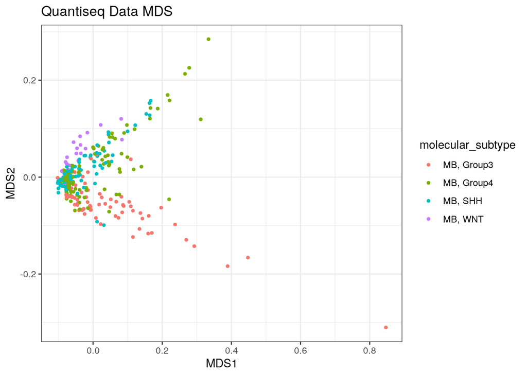

```r
mds_result <- cmdscale(qs_dist_mat,k=2)
mds_df <- data.frame(
    Kids_First_Biospecimen_ID = qs_data_trans$Kids_First_Biospecimen_ID,
    molecular_subtype = qs_data_trans$molecular_subtype,
    MDS1 = mds_result[,1],
    MDS2 = mds_result[,2]
)
qs_mds_plot <- mds_df %>%
    ggplot(aes(x=MDS1,y=MDS2,color=molecular_subtype)) +
        geom_point(size=1) +
        ggtitle('Quantiseq Data MDS') +
        theme_bw()
show(qs_mds_plot)
```

## Hypothesis Testing the Difference of Each Cell Type Across Molecular Subtypes

We can employ the Kruskal-Wallis test to assess whether there are differences in the proportion of each cell type across all 4 molecular subtypes and apply the Benjamini-Hochberg false discovery rate correction to correct for multiple comparisons.

```r
# Kruskal-Wallis Test per cell type
qs_data_by_cell <- qs_data %>%
    mutate(molecular_subtype = factor(molecular_subtype)) %>%
    split(qs_data$cell_type)
kw_pval <- list()
for (cell in names(qs_data_by_cell)) {
    kw_result <- kruskal.test(fraction ~ molecular_subtype,qs_data_by_cell[[cell]])
    kw_pval[[cell]] <- kw_result$p.value
}
# FDR correction and formatting number for display on plot
adj.pval <- scales::label_scientific(digits=3)(p.adjust(kw_pval,method='BH'))
adj.pval <- lapply(adj.pval,\(x)str_glue('p={x}'))
```

## Visualize Quantiseq Estimated Cell Fractions

Here we visualize the differences between cell type proportions as a swarm plot. Horizontal black lines indicate the median proportion across all samples in the sub group. P-values are Benjamini-Hochberg corrected Kruskal-Wallis p-values for each cell type.

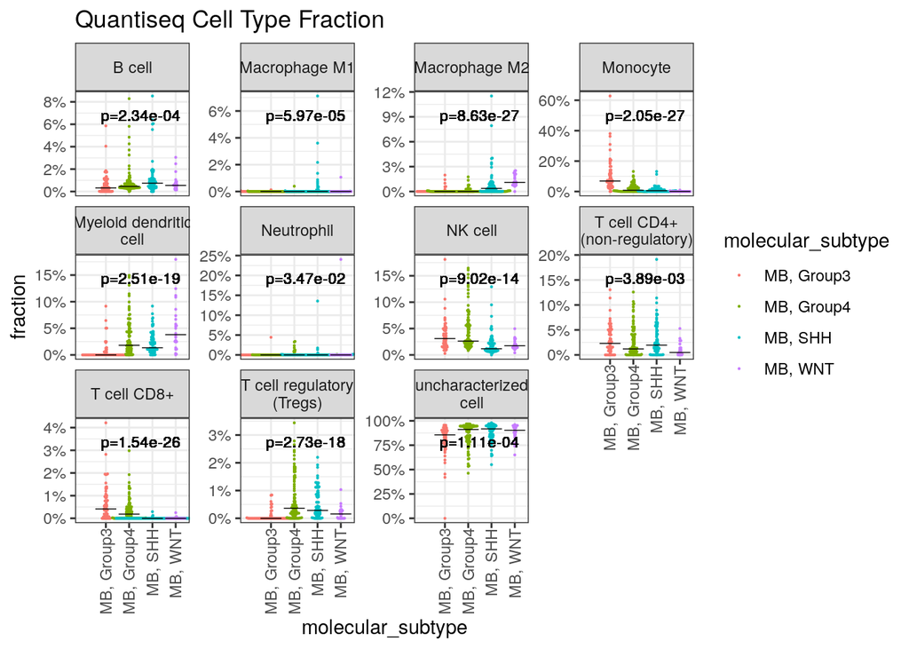

```r
qs_swarmplot <- qs_data %>%
    mutate(p.adj = recode(cell_type,!!!adj.pval)) %>%
    group_by(cell_type) %>%
    mutate(y_pos = .8*max(fraction)) %>%
    ungroup() %>%
    ggplot(aes(x=molecular_subtype,y=fraction,color = molecular_subtype)) +
        geom_beeswarm(size=.1) +
        stat_summary(fun=median,color='black',geom='crossbar',linewidth = .1) +
        geom_text(aes(x=2.5,y=y_pos,label=p.adj),color='black',size=3,alpha=.5) +
        # ggpubr::stat_kruskal_test(p.adjust.method='BH', label.y.npc = .7,label='p.adj') +
        facet_wrap(~ cell_type,scales = 'free_y',labeller = label_wrap_gen(20)) +
        scale_y_continuous(labels = scales::percent) +
        ggtitle('Quantiseq Cell Type Fraction') +
        theme_bw() %+replace%
        theme(axis.text.x = element_text(angle=90,hjust=.95))

if (!dir.exists('fig')) {
    dir.create('fig')
}
ggsave(plot=qs_swarmplot,filename = 'fig/fig1.pdf',height=8,width=12)
show(qs_swarmplot)
```

## Statistical analysis of differential Immune Cell Type Scores determined by XCell

XCell outputs scores for cell types instead of proportions. The sample scores DO NOT sum to 1.

```r
xcell_data_trans <- xcell_data
xcell_data_trans <- xcell_data_trans %>%
    dplyr::select(Kids_First_Biospecimen_ID,molecular_subtype,cell_type,fraction) %>%
    tidyr::pivot_wider(
        names_from='cell_type',
        values_from='fraction',
        id_cols=c('Kids_First_Biospecimen_ID','molecular_subtype')
    )
xcell_dist_mat <- vegan::vegdist(xcell_data_trans[,3:ncol(xcell_data_trans)],method = 'bray')
set.seed(117)
permanova_result <- vegan::adonis2(xcell_dist_mat ~ xcell_data_trans$molecular_subtype)
print(permanova_result)
```

```
## Permutation test for adonis under reduced model
## Permutation: free
## Number of permutations: 999
##
## vegan::adonis2(formula = xcell_dist_mat ~ xcell_data_trans$molecular_subtype)
##           Df SumOfSqs      R2    F Pr(>F)
## Model      3    5.457 0.14267 15.2  0.001 ***
## Residual 274   32.794 0.85733
## Total    277   38.251 1.00000
## ---
## Signif. codes:  0 '***' 0.001 '**' 0.01 '*' 0.05 '.' 0.1 ' ' 1
```

PERMANOVA shows that molecular subtypes have significantly different cell compositions.

## Dimension Reduction of Cell Type Proportion Data by Multidimensional Scaling (MDS)

We can produce an MDS plot to look at overall differences in proportion using the previously computed Bray-Curtis distance matrix. On the MDS plot below we can see differences between molecular subtypes.

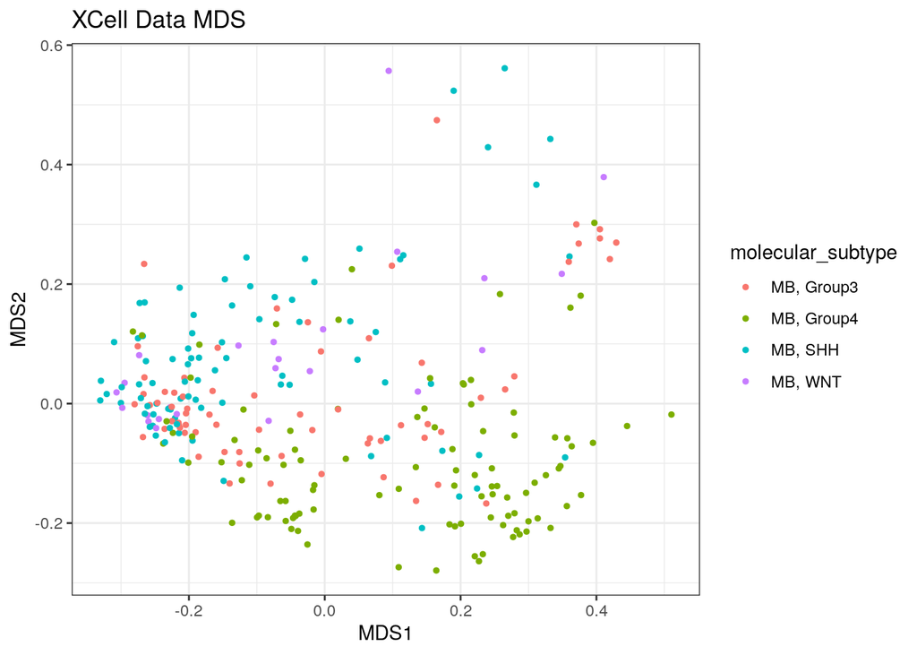

```r
xcell_mds_result <- cmdscale(xcell_dist_mat,k=2)
mds_df <- data.frame(
    Kids_First_Biospecimen_ID = xcell_data_trans$Kids_First_Biospecimen_ID,
    molecular_subtype = xcell_data_trans$molecular_subtype,
    MDS1 = xcell_mds_result[,1],
    MDS2 = xcell_mds_result[,2]
)
xcell_mds_plot <- mds_df %>%
    ggplot(aes(x=MDS1,y=MDS2,color=molecular_subtype)) +
        geom_point(size=1) +
        ggtitle('XCell Data MDS') +
        theme_bw()
show(xcell_mds_plot)
```

## Hypothesis Testing the Difference of Each Cell Type Across Molecular Subtypes

We can employ the Kruskal-Wallis test to assess whether there are differences in the proportion of each cell type across all 4 molecular subtypes and apply the Benjamini-Hochberg false discovery rate correction to correct for multiple comparisons.

```r
# Kruskal-Wallis Test per cell type
xcell_data_by_cell <- xcell_data %>%
    mutate(molecular_subtype = factor(molecular_subtype)) %>%
    split(xcell_data$cell_type)
kw_pval <- list()
for (cell in names(xcell_data_by_cell)) {
    kw_result <- kruskal.test(fraction ~ molecular_subtype,xcell_data_by_cell[[cell]])
    kw_pval[[cell]] <- kw_result$p.value
}
bh_pval <- p.adjust(kw_pval,method='BH')
adj.pval <- scales::label_scientific(digits=3)(bh_pval)
adj.pval <- lapply(adj.pval,\(x)str_glue('p={x}'))
xcell_kw_results <- data.frame(cell_type = names(kw_pval),p=as.numeric(kw_pval),p.adj = as.numeric(bh_pval))
```

## Differentially Abundant XCell Predicted Cell Types according to Kruskal-Wallis Test

```r
print(dplyr::filter(xcell_kw_results,p.adj<.01))
```

```
##                           cell_type            p        p.adj
## 1                            B cell 4.865634e-03 9.731268e-03
## 2                      B cell naive 1.378003e-05 3.543437e-05
## 3                     B cell plasma 2.747057e-13 2.472352e-12
## 4      Cancer associated fibroblast 4.264024e-09 1.918811e-08
## 5      Class-switched memory B cell 1.644220e-14 2.951960e-13
## 6        Common lymphoid progenitor 6.508376e-04 1.464384e-03
## 7           Hematopoietic stem cell 3.360843e-20 1.209903e-18
## 8                        Macrophage 7.288403e-06 2.018327e-05
## 9                     Macrophage M1 2.019887e-09 1.083876e-08
## 10                    Macrophage M2 2.022206e-06 6.539511e-06
## 11 Myeloid dendritic cell activated 5.628053e-08 2.251221e-07
## 12      Plasmacytoid dendritic cell 2.459966e-14 2.951960e-13
## 13       T cell CD4+ central memory 2.179837e-06 6.539511e-06
## 14      T cell CD4+ effector memory 2.012585e-05 4.830205e-05
## 15                T cell CD4+ naive 1.845725e-03 3.908594e-03
## 16                  T cell CD4+ Th1 8.877330e-10 6.391678e-09
## 17                T cell CD8+ naive 5.924703e-07 2.132893e-06
## 18                        T cell NK 2.107536e-09 1.083876e-08
```

## Visualize XCell Estimated Cell Fractions

Here we visualize the differences between cell type proportions as a swarm plot. Horizontal black lines indicate the median proportion across all samples in the sub group. P-values are Benjamini-Hochberg corrected Kruskal-Wallis p-values for each cell type.

```r
# add p-values and compute coordinates for geom_text
xcell_data <- xcell_data %>%
    mutate(p.adj = recode(cell_type,!!!adj.pval)) %>%
    group_by(cell_type) %>%
    mutate(y_pos = .8*max(fraction)) %>%
    ungroup()
xcell_swarmplot <- xcell_data %>%
    ggplot(aes(x=molecular_subtype,y=fraction,color = molecular_subtype)) +
        geom_beeswarm(size=.1) +
        stat_summary(fun=median,color='black',geom='crossbar',linewidth = .1) +
        geom_text(aes(x=2.5,y=y_pos,label=p.adj),color='black',size=3,alpha=.5) +
        # ggpubr::stat_kruskal_test(p.adjust.method='BH', label.y.npc = .7,label='p.adj') +
        facet_wrap(~ cell_type,scales = 'free_y',labeller = label_wrap_gen(12)) +
        scale_y_continuous(labels = scales::percent) +
        ggtitle('XCell Cell Type Fraction') +
        theme_bw() %+replace%
        theme(axis.text.x = element_text(angle=90,hjust=.95))

if (!dir.exists('fig')) {
    dir.create('fig')
}
ggsave(plot=xcell_swarmplot,filename = 'fig/fig2.pdf',height=12,width=16)
```

Here we examine whether each cell type has a different distribution across all 4 molecular subtypes. We plot each cell type separately for legibility.

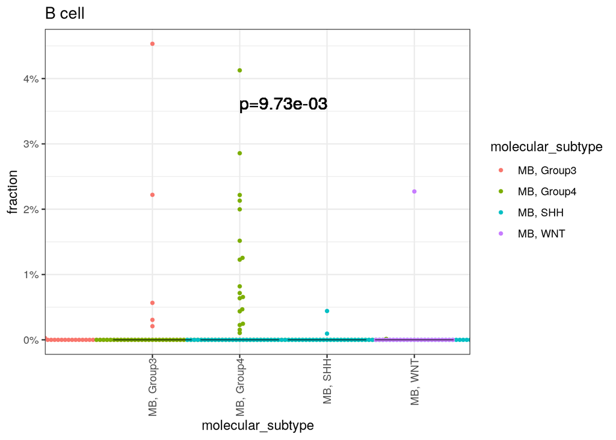

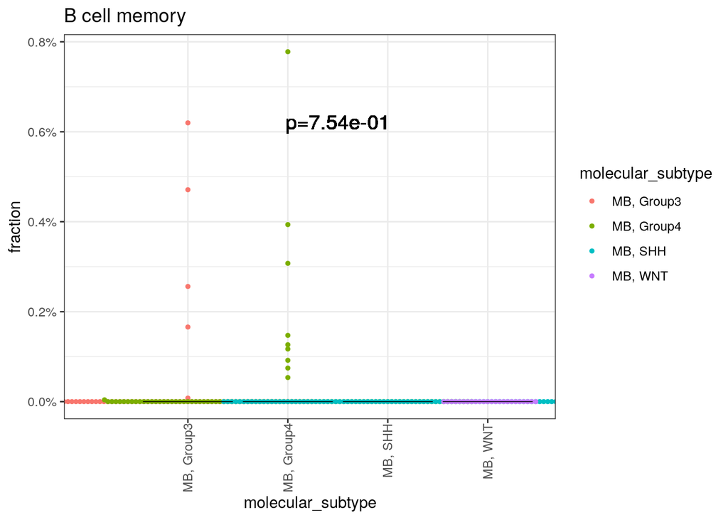

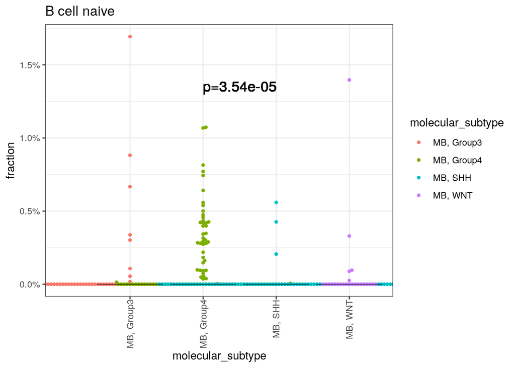

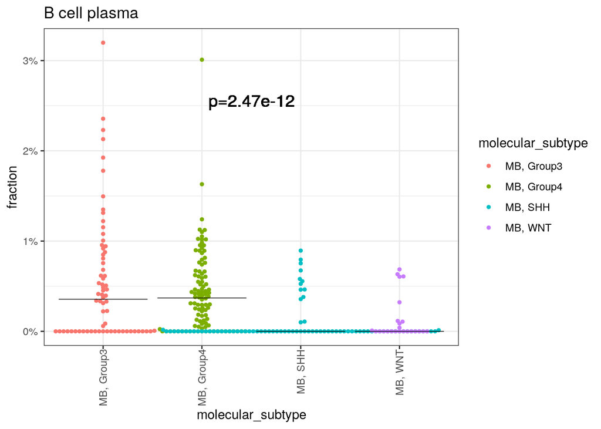

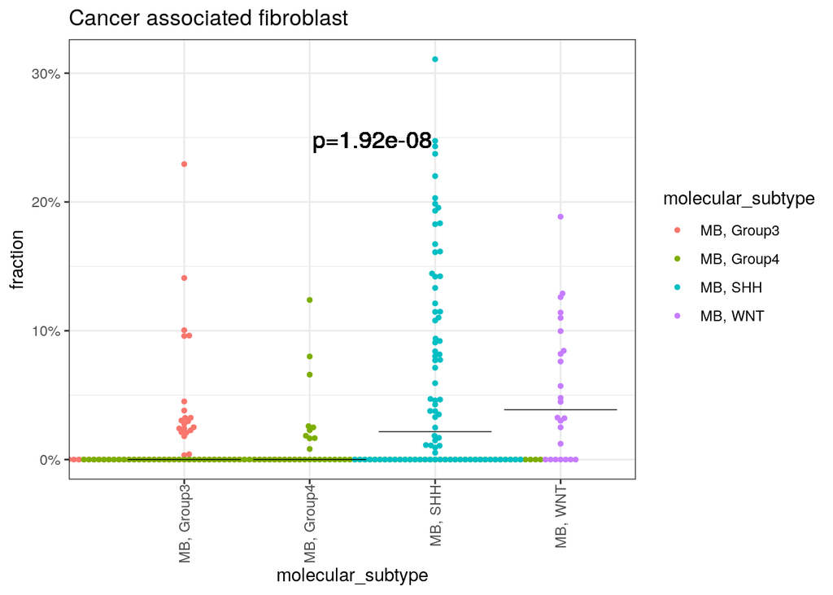

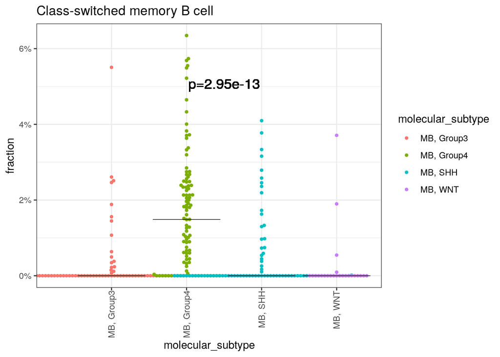

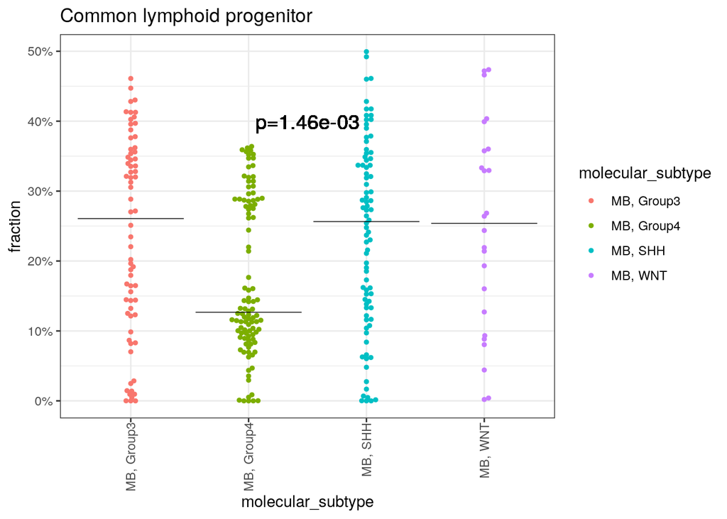

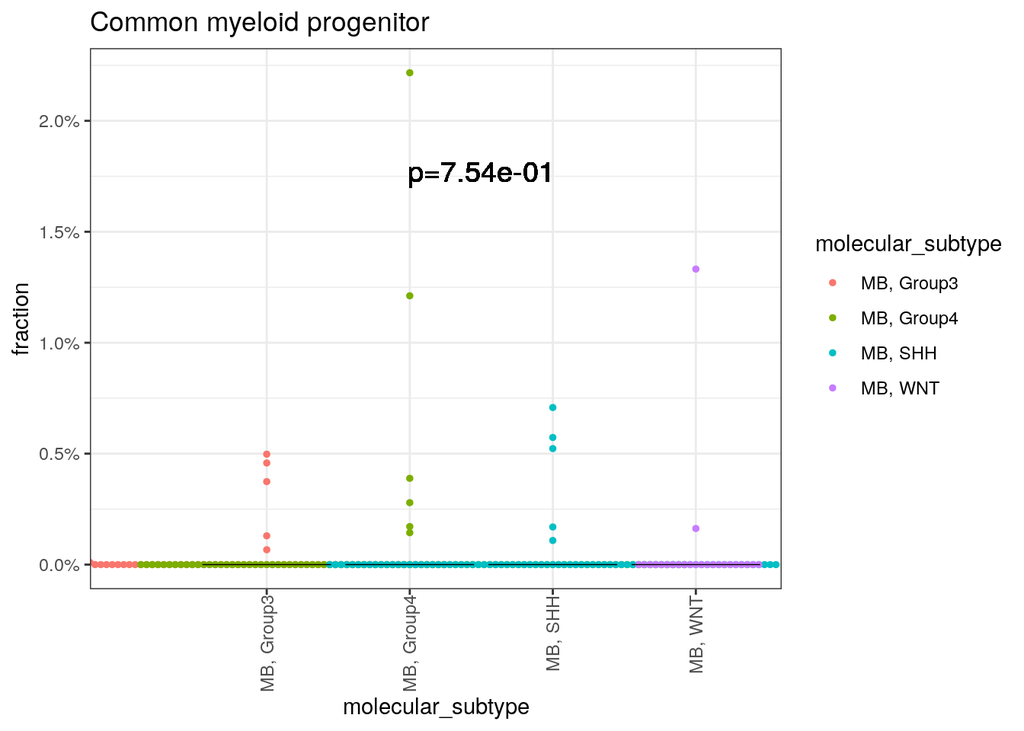

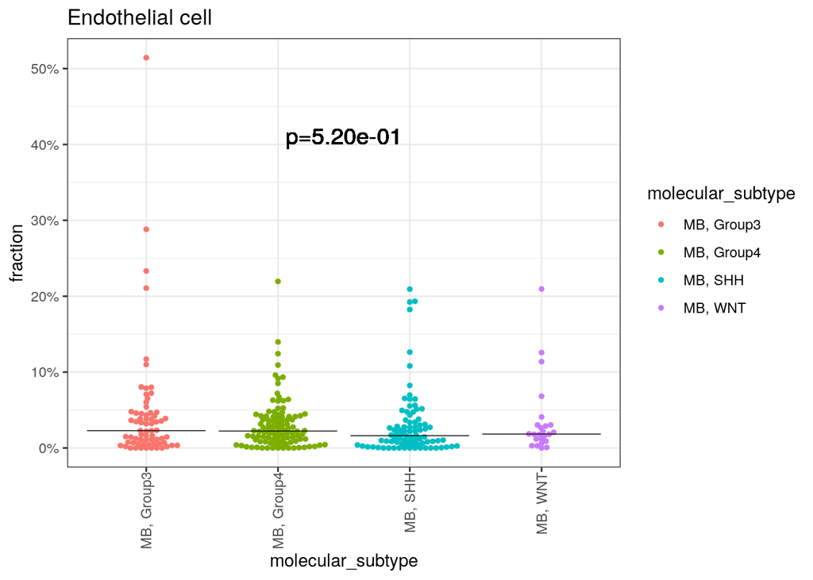

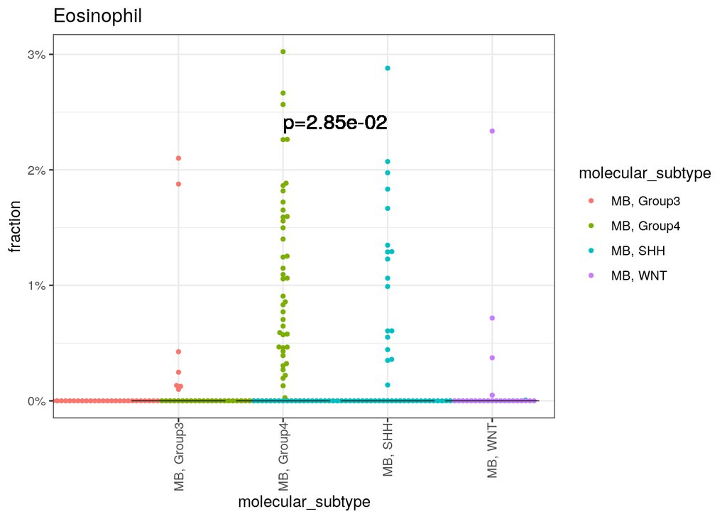

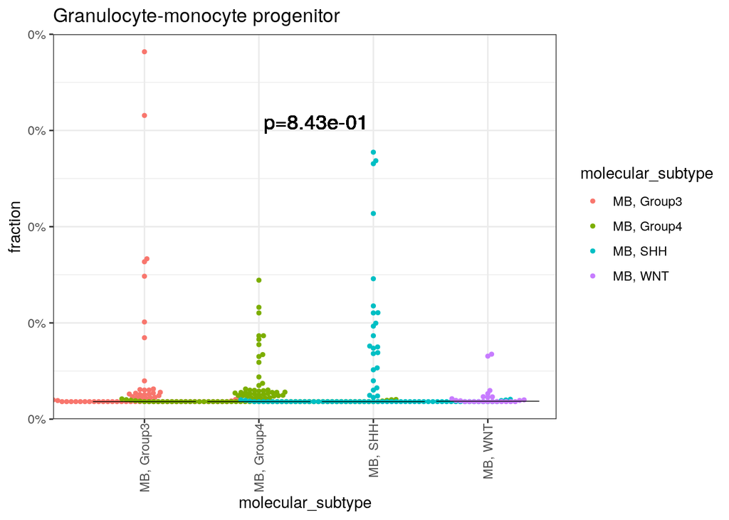

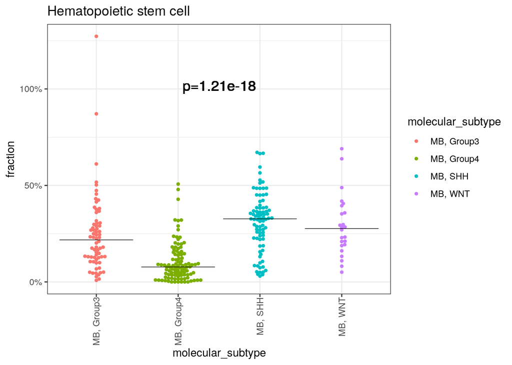

[24 more figures not shown]

```r
# plot every cell type individually because the facet_grid plot doesn't show up well in html
xcell_data_by_cell <- xcell_data %>%
    mutate(molecular_subtype = factor(molecular_subtype)) %>%
    split(xcell_data$cell_type)
for (cell in names(xcell_data_by_cell)) {
    swarmplot <- xcell_data_by_cell[[cell]] %>%
        ggplot(aes(x=molecular_subtype,y=fraction,color = molecular_subtype)) +
            geom_beeswarm(size=1) +
            stat_summary(fun=median,color='black',geom='crossbar',linewidth = .1) +
            geom_text(aes(x=2.5,y=y_pos,label=p.adj),color='black',size=5,alpha=.5) +
            # ggpubr::stat_kruskal_test(p.adjust.method='BH', label.y.npc = .7,label='p.adj') +
            scale_y_continuous(labels = scales::percent) +
            ggtitle(cell) +
            theme_bw() %+replace%
            theme(axis.text.x = element_text(angle=90,hjust=.95))
    show(swarmplot)
}
```